# GLM-Based GWAS Analysis

NosheenFatima

`23/2/2025`

### Table of Contents

1. Introduction
2. Logo
3. Installation Guide
4. Package Log
5. Understanding Input File Structure
6. Load Required Libraries
7. Define GWAS Function
8. Generate Visualization

## 1. Introduction

This document presents a framework for performing genome-wide association studies (GWAS) using a generalized linear model (GLM). The package integrates principal component analysis (PCA) to account for population structure, enhancing the accuracy of association testing. Following the analysis, it provides visualization tools, including Manhattan plots for SNP significance mapping and quantile-quantile (QQ) plots to assess the model fit and p-value distributions.

## 2. Logo

[output not shown]

## 3. Installation Guide

If you have not installed R or RStudio, you can download them based on your requirements:

- **R**: Download from [CRAN](https://cran.r-project.org/).
- **RStudio**: Download from [Posit](https://posit.co/download/rstudio-desktop/).

### Installing Glimp from GitHub

To download files off GitHub, first, install and load the `devtools` package

Now, install the Glimp package from GitHub:

```r
devtools::install_github("NosheenFatima27/Glimp")
library(Glimp)
```

[figure not shown]

## 4. Package Log

The following packages are required and used in this analysis:

```r
# Load necessary packages
library(ggplot2)  # For plotting Manhattan and QQ plots
library(knitr)    # For dynamic report generation
library(kableExtra) # For improved table rendering
```

## 5. Understaing input File Structure

The following files are required:

- **GD1.csv**: Genotype matrix (taxa in rows, SNPs in columns).
- **SNPinfo.csv**: SNP information file containing columns for SNP names, chromosomes, and positions.
- **Phenotype.csv**: Phenotypic data with at least one phenotype column.
- **Covariates.csv** (Optional): Additional covariates for population structure correction.

### Example Structure

Genotype Data

| Taxa | SNP1 | SNP2 | SNP3 |
| --- | --- | --- | --- |
| Sample1 | 0 | 1 | 2 |
| Sample2 | 1 | 0 | 2 |

SNP Information

| SNP | Chromosome | Position |
| --- | --- | --- |
| SNP1 | 1 | 10000 |
| SNP2 | 1 | 10500 |

Phenotypic Data

| Taxa | Trait1 |
| --- | --- |
| Sample1 | 2.1 |
| Sample2 | 3.5 |

Covariates Data

| Taxa | Factor1 | Factor2 |
| --- | --- | --- |
| Sample1 | 1 | 0 |
| Sample2 | 0 | 1 |

## 6. Load Required Libraries

```r
library(ggplot2)
library(knitr)
```

## 7. Define GWAS Function

```r
gwas_glm <- function(y, X, C = NULL, include_pcs = FALSE, npcs = 5) {
  # Ensure response variable length matches genotype data rows
  if (length(y) != nrow(X)) stop("Length of y must match the number of rows in X.")
  if (!is.null(C) && nrow(C) != length(y)) stop("Number of rows in C must match length of y.")
 # If PCA adjustment is enabled, compute principal components
  if (include_pcs) {
    C <- pca_adjustment(X, C, npcs)$adjusted_covariates
  }

  m <- ncol(X) # Number of SNPs
  pvals <- numeric(m) # Initialize vector to store p values
# Loop through each SNP to fit GLM model
  for (i in 1:m) {
    model_data <- data.frame(y = y, marker = X[, i])# Create dataset for modeling
    if (!is.null(C)) model_data <- cbind(model_data, C)#Include covariates if provided

    fit <- tryCatch(
      glm(y ~ ., data = model_data, family = gaussian()),# Fit GLM model
      error = function(e) {
        warning(paste("GLM failed for marker", i, "- setting p-value to 1"))
        return(NULL)
      }
    )

    if (!is.null(fit)) {
      coef_summary <- summary(fit)$coefficients
      if ("marker" %in% rownames(coef_summary)) {
        pvals[i] <- coef_summary["marker", "Pr(>|t|)"]# Extract p-value
      } else {
        pvals[i] <- 1# Assign maximum p-value if marker is absent
      }
    } else {
      pvals[i] <- 1# Assign maximum p-value if GLM fails
    }
  }

  return(pvals)# Return p-valuees
}
```

## 8. Define Manhattan and QQ Plot Functions

```r
manhattan_plot <- function(pvals, myGM) {
  plot_data <- data.frame(
    SNP = myGM$SNP,
    Chromosome = factor(myGM$Chromosome, levels = unique(myGM$Chromosome)),
    Position = myGM$Position,
    P = pvals
  )

  plot_data$logP <- -log10(plot_data$P)
  threshold <- -log10(0.05 / nrow(myGM))

  ggplot(plot_data, aes(x = Chromosome, y = logP, color = Chromosome)) +
    geom_jitter(width = 0.4, height = 0, alpha = 0.7, size = 1.5) +
    geom_hline(yintercept = threshold, linetype = "dashed", color = "red") +
    labs(title = "Manhattan Plot", x = "Chromosome", y = "-log10(p-value)") +
    theme_minimal() +
    theme(axis.text.x = element_text(angle = 45, hjust = 1), legend.position = "none")
}

qq_plot <- function(pvals) {
  obs <- -log10(sort(pvals))
  exp <- -log10(ppoints(length(pvals)))
  qq_data <- data.frame(Expected = exp, Observed = obs)

  ggplot(qq_data, aes(x = Expected, y = Observed)) +
    geom_point() +
    geom_abline(slope = 1, intercept = 0, color = "red", linetype = "dashed") +
    labs(title = "QQ Plot", x = "Expected -log10(p-value)", y = "Observed -log10(p-value)") +
    theme_minimal()
}
```

## Load Data

```r
myGD <- read.csv("/Users/nosheenfatima/Documents/WSU course folders/Statistical Genomics/HW1/mydata/GD1.csv", header = TRUE, row.names = 1)
myGM <- read.csv("/Users/nosheenfatima/Documents/WSU course folders/Statistical Genomics/HW1/mydata/SNPinfo.csv", header = TRUE)
Phenotype <- read.csv("/Users/nosheenfatima/Documents/WSU course folders/Statistical Genomics/HW1/mydata/Phenotype.csv", header = TRUE)

# Convert genotype data to matrix and remove the taxa column
X <- myGD  # Ensure all columns are numeric

y <- as.numeric(Phenotype[, 2])  # Extract phenotype column as a numeric vector

# Run GWAS
pvals <- gwas_glm(y, X, C= NULL, include_pcs = FALSE, npcs = 3)
print(head(pvals, 10))
```

```
##  [1] 0.6890898 0.7071557 0.7565259 0.7740388 0.7218360 0.6350104 0.9964281
##  [8] 0.5917979 0.9299803 0.8587652
```

```r
# Print summary statistics
cat("GWAS Completed!\n")
```

```
## GWAS Completed!
```

## run MAF function and call significant SNPs

```r
X_maf <- X  # Create a copy
for (col in colnames(X_maf)) {
  X_maf[[col]] <- suppressWarnings(as.numeric(as.character(X_maf[[col]])))  # Convert only numeric columns
}
# Compute MAF using X_maf
compute_maf <- function(X) {
  X <- as.matrix(X)  # Convert to matrix inside function to avoid errors
  allele_freq <- colMeans(X, na.rm = TRUE) / 2  # Calculate allele frequency
  maf <- pmin(allele_freq, 1 - allele_freq)  # Compute MAF
  return(maf)
}

maf_values <- compute_maf(X_maf)  # Use X_maf instead of X

# Set genome-wide significance threshold
threshold <- 0.05 / ncol(X_maf)  # Use X_maf

# Extract significant SNPs
significant_snps <- which(pvals < threshold)

# Print significant SNPs with MAF
if (length(significant_snps) > 0) {
  cat("List of Significant SNPs:\n")
  print(data.frame(
    SNP = myGM$SNP[significant_snps],
    Chromosome = myGM$Chromosome[significant_snps],
    Position = myGM$Position[significant_snps],
    P_Value = pvals[significant_snps],
    MAF = maf_values[significant_snps]  # Use maf_values from X_maf
  ))
} else {
  cat("No significant SNPs found.\n")
}
```

```
## List of Significant SNPs:
##                                 SNP Chromosome  Position      P_Value       MAF
## CHS21_3B699464487 CHS21_3B699464487         3B 699464487 1.279264e-05 0.2750000
## CHS21_3B701574383 CHS21_3B701574383         3B 701574383 7.104126e-06 0.2861111
## CHS21_3B703992833 CHS21_3B703992833         3B 703992833 3.111893e-05 0.2833333
## CHS21_3B723147320 CHS21_3B723147320         3B 723147320 3.936323e-06 0.2777778
## CHS21_3B725280975 CHS21_3B725280975         3B 725280975 2.596532e-06 0.2722222
## CHS21_3B730648524 CHS21_3B730648524         3B 730648524 2.596532e-06 0.2722222
## CHS21_3B738159002 CHS21_3B738159002         3B 738159002 1.909867e-06 0.2777778
## CHS21_3B738362703 CHS21_3B738362703         3B 738362703 1.909867e-06 0.2777778
## CHS21_3B745958395 CHS21_3B745958395         3B 745958395 1.205506e-05 0.2888889
## CHS21_3B748274559 CHS21_3B748274559         3B 748274559 1.684067e-05 0.2888889
## CHS21_3B753176661 CHS21_3B753176661         3B 753176661 3.716627e-06 0.2722222
## CHS21_3B760576701 CHS21_3B760576701         3B 760576701 3.878988e-07 0.2583333
## CHS21_3B762655923 CHS21_3B762655923         3B 762655923 1.545763e-06 0.2611111
## CHS21_3B768030352 CHS21_3B768030352         3B 768030352 4.292007e-06 0.2694444
## CHS21_3B772776077 CHS21_3B772776077         3B 772776077 4.555087e-06 0.2611111
## CHS21_3D134598936 CHS21_3D134598936         3D 134598936 1.818837e-05 0.2527778
```

## Generate plots for visualization

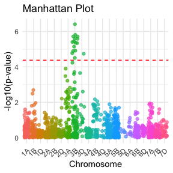

```r
manhattan_plot(pvals, myGM)
```

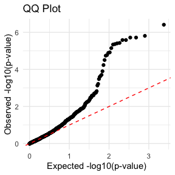

```r
qq_plot(pvals)
```